# Book Recommender System

STA5073Z Assignment 1

Author

Tinotenda Muzambi (MZMTIN002)

# Introduction

In the age of information overload, recommender systems have become indispensable tools for helping users navigate vast catalogs of products and content. This report details the development of a book recommender system that leverages multiple approaches to provide recommendations. Our system combines user-based collaborative filtering (UBCF), item-based collaborative filtering (IBCF), matrix factorization (MF), and an ensemble model to create a robust recommendation engine.

## User-Based Collaborative Filtering

UBCF operates on the principle that users with similar reading preferences in the past are likely to have similar preferences in the future. This approach identifies users with similar reading histories and recommends books that these similar users have enjoyed but the target user hasn’t yet read.<sup>[1]</sup>

The motivation behind UBCF is its ability to capture complex user preferences that may not be easily describable by item features alone. It can uncover unexpected recommendations based on the collective wisdom of similar users, potentially leading to serendipitous discoveries.<sup>[2]</sup>

## Item-Based Collaborative Filtering

Item-based collaborative filtering (IBCF) focuses on the relationships between items rather than users. It assumes that users will prefer items similar to those they’ve liked in the past. IBCF calculates similarity between books based on user rating patterns and recommends books similar to those the user has already rated highly.<sup>[3]</sup>

The primary motivation for IBCF is its scalability and stability compared to UBCF, especially in systems where the number of items is significantly smaller than the number of users. It’s also less affected by the entry and exit of users from the system, making it more robust to user churn.<sup>[2]</sup>

## Matrix Factorisation

Matrix factorization is a latent factor model that aims to uncover hidden features that explain observed rating patterns. It works by decomposing the user-item interaction matrix into lower-dimensional user and item matrices. These lower-dimensional representations can capture nuanced aspects of user preferences and item characteristics that aren’t explicitly modeled.<sup>[4]</sup>

The motivation for including matrix factorization is its ability to handle sparsity in the rating matrix and its capacity to generalize to unseen user-item interactions. It often outperforms memory-based approaches (like UBCF and IBCF) in terms of accuracy and can provide recommendations even when explicit rating data is limited.<sup>[5]</sup>

# The Data

The data is a partially preprocessed version of the ”Book-Crossing” dataset consisting of three datasets: Ratings, Books, and Users. The Ratings dataset contains the ratings given by users to books. The Books dataset contains information about the books, such as the title and year of publication. The Users dataset contains information about the users, such as their age. The data can be downloaded [here](https://www.kaggle.com/datasets/arashnic/book-recommendation-dataset/) from Kaggle. It contains 278 858 users providing 1 149 780 ratings about 271 379 books.

A description of the features in each dataset is provided below:

- Ratings:
  - User.ID: Unique identifier for the user.
  - ISBN: Unique identifier for the book.
  - Book.Rating: Rating given by the user to the book.
- Books:
  - ISBN: Unique identifier for the book.
  - Book.Title: Title of the book.
  - Book.Author: Author of the book.
  - Year.Of.Publication: Year the book was published.
  - Publisher: Publisher of the book.
  - Image.URL.S: URL of the book cover in small size.
  - Image.URL.M: URL of the book cover in medium size.
  - Image.URL.L: URL of the book cover in large size.
- Users:
  - User.ID: Unique identifier for the user.
  - Location: Location of the user.
  - Age: Age of the user.

# Data Pre-processing

We will merge the Books, Ratings and User datasets into a single dataframe. This will make working with the data easier. Due to the large size of the data, we will then perform various functions to reduce the number of observations.

This will serve the purposes of both reducing the size of the data and ensuring that we have enough data to build accurate models. This is important as collaborative filtering models require a certain amount of data to make accurate predictions.

We will also perform some data cleaning. Part of which includes recoding the user and book IDs to be sequential integers starting from 0. This is necessary for the `recosystem` package which will be used in the matrix factorisation model.

# Exploratory Data Analysis

We perform some exploratory data analysis to understand the data better by looking at the structure and summary of the data. We also look at the distribution of the ratings, age, and year of publication to understand the data better.

Looking at the structure and summary of the data, we identify some cleaning that needs to be done. We will do the following to clean up the data:

- Remove the columns that we do not need.
- Replace ages less than 13 and greater than 100 with NA.
- Convert the data types of the columns to the appropriate types.
- Replace year of publication with NA where it is before 1900.
- Remove any rows with missing values.

We will look at the distribution of the ratings, age, and year of publication to understand the data better. We will use histograms to visualise the distributions.

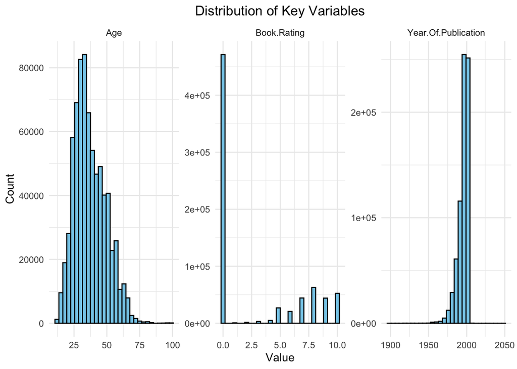

Figure 1: Distribution of Key Variables

Before building the recommendation systems, we will drop users and books with less than five ratings and only keep the columns we need for the analysis. Namely, the user ID, ISBN, book rating and the book title. We will also then take a sample of 35 000 ratings for computational efficiency.

We will now look at the distribution of the ratings after removing the zero ratings. Figure 2 depicts the distribution of the ratings. It shows that most of the ratings are between 5 and 10. This is expected as users are more likely to rate books that they enjoyed.

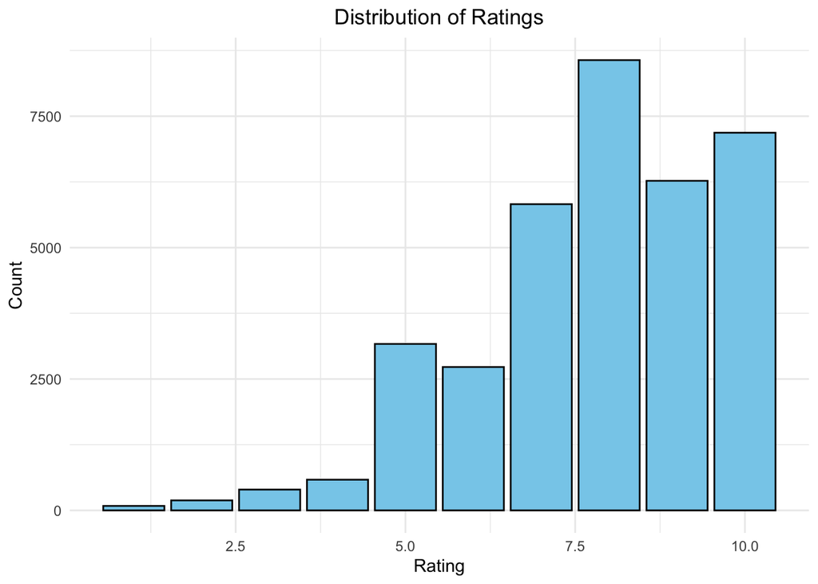

Figure 2: Distribution of Ratings

# Recommendation Systems

We begin building our recommendation systems by building a UBCF system. We then build an IBCF system. Finally, we build a MF system before creating an ensemble model that combines the three models.

## User-Based Collaborative Filtering

We start by building a UBCF system. User based collaborative filtering finds users with similar consumption patterns as yourself and gives you the content that these similar users found interesting.<sup>[6]</sup> How it works is that it first creates a user-item matrix. The user-item matrix is a matrix where the rows represent users, the columns represent items, and the cells represent the ratings given by users to items. This matrix is then used to calculate the cosine similarity between users. We then use the similarity matrix to predict the ratings for the books.

## Item-Based Collaborative Filtering

We then build an IBCF system. IBCF uses similarity between the items to determine whether a user would like it or not. The same matrix created in the UBCF system is used. This matrix is used to calculate the cosine similarity between items. We then use the similarity matrix to predict the ratings for the books.

## Matrix Factorisation

We then build a matrix factorisation system using recosystem. Matrix factorization is an extensively used technique in collaborative filtering recommendation systems. Its objective is to factorise a user-item matrix into two low-ranked matrices, the user-factor matrix and the item-factor matrix, that can predict new items that users might be interested in. This is achieved in by multiplying the two factor matrices.<sup>[7]</sup>

We first allocate training and test splits before setting up the model. We also perform some hyperparameter tuning to find the best values for the learning rate and dim. We then make predictions on the test set in order to evaluate the accuracy of the model using Root Mean Square Error(RMSE). The root mean square error (RMSE) measures the average difference between a statistical model’s predicted values and the actual values.<sup>[8]</sup> We then apply regularisation to the model and evaluate the accuracy again.

### Hyperparameter Tuning

The initial grid for the hyperparameter search involved varying `dim` from 0 - 50 and `lrate` from 0.01 - 0.1. From the initial search the optimal parameters were `dim` = 50 and `lrate` = 0.1. Since these values were on the edge of the grid, we performed another search with `dim` varying from 50 - 100 and `lrate` from 0.1 - 0.5. The optimal parameters found were `dim` = 75 and `lrate` = 0.1. The model is then retrained with these optimal hyperparameters.

### Model Evaluation

With the models set up, we can do some testing. We start by creating the ratings matrix. Predictions are then made on the test set to then evaluate the accuracy of the matrix factorisation model using RMSE. We then apply regularisation to the model and evaluate the accuracy again.

The RMSE of the matrix factorisation model without regularisation was foundt to be 1.84. This tells us that on average, the model’s predictions are off by 1.84 units. We now apply regularisation to the model and evaluate the accuracy again.

### Regularisation

With regularisation, the RMSE of the matrix factorisation model is 1.84. This tells us that on average, the model’s predictions are off by 1.84 units. Compared to the RMSE of the matrix factorisation model without regularisation, the regularised model is approximately the same. This could be due to the fact that the model was already performing well without regularisation. Regularisation is used to prevent overfitting and improve the generalisation of the model. In this case, the model was already generalising well without regularisation.

## Ensemble Model

We now create an ensemble model that combines the UBCF, IBCF, and MF models. We then evaluate the accuracy of the ensemble model using RMSE. The ensemble model will be created by simply averaging the predictions of the three models.

The RMSE of the ensemble model is 2.93. This tells us that on average, the model’s predictions are off by 2.93 units. Compared to the RMSE of the matrix factorisation model of 1.84, the ensemble model is less accurate. This could be due to the fact that the ensemble model is a simple average of the three models. More sophisticated ensemble methods could be used to improve the accuracy of the ensemble model. Namely, methods that take into account the performance of the individual models and assign weights to the models based on their performance. This would allow the ensemble model to take advantage of the strengths of the individual models and improve the accuracy of the predictions. However, the ensemble model is still useful as it combines the strengths of the UBCF, IBCF, and MF models and provides a more robust recommendation engine.

# Conclusion

In this project, we built a book recommendation system using collaborative filtering and matrix factorisation. We started by loading the data and performing some data pre-processing. We then built a user-based collaborative filtering system, an item-based collaborative filtering system, and a matrix factorisation system. We evaluated the accuracy of the models using RMSE. Finally, we created an ensemble model that combines the user-based collaborative filtering, item-based collaborative filtering, and matrix factorisation models. The ensemble model was evaluated using RMSE. The results showed that the matrix factorisation model had a lower RMSE compared to the ensemble model. The ensemble model is a simple average of the three models and could be improved by using more sophisticated ensemble methods. Overall, the book recommendation system provides a robust recommendation engine that combines the strengths of the UBCF, IBCF, and MF models.

## References

1. Su, X. (2009). *A survey of collaborative filtering techniques*.

2. Ricci, F., Rokach, L., & Shapira, B. (2010). Introduction to recommender systems handbook. In *Recommender systems handbook* (pp. 1–35). Springer.

3. Sarwar, B., Karypis, G., Konstan, J., & Riedl, J. (2001). Item-based collaborative filtering recommendation algorithms. *Proceedings of the 10th International Conference on World Wide Web*, 285–295.

4. Koren, Y., Bell, R., & Volinsky, C. (2009). Matrix factorization techniques for recommender systems. *Computer*, *42*(8), 30–37.

5. Aggarwal, C. C. et al. (2016). *Recommender systems* (Vol. 1). Springer.

6. Boström, P., & Filipsson, M. (2017). *Comparison of user based and item based collaborative filtering recommendation services*.

7. Isinkaye, F. O. (2023). Matrix factorization in recommender systems: Algorithms, applications, and peculiar challenges. *IETE Journal of Research*, *69*(9), 6087–6100.

8. Frost, J. *Root Mean Square Error (RMSE) — statisticsbyjim.com*. https://statisticsbyjim.com/regression/root-mean-square-error-rmse/.